# Covid-19 Data

Tina L.

2024-06-23

## Project File

This report will analyze the COVID-19 Data by the Center for Systems Science and Engineering (CSSE) at Johns Hopkins University. More information about the data can be found on https://github.com/CSSEGISandData/COVID-19. This project file follows the tutorial of the week 3 module of the course Data Science as a field. It explains the steps that Dr.Jane Wall took to analyze the COVID-19 data sets. It includes some additional data visualization as well.

This report will look at the global and US COVID-19 cases, which comes in 4 csv files:  
- “time_series_covid19_confirmed_global.csv”,  
- “time_series_covid19_deaths_global.csv”,  
- “time_series_covid19_confirmed_US.csv”,  
- “time_series_covid19_deaths_US.csv”

The purpose of this project file is to go over the data process flow of analyzing a data file in R.

## Importing Data

Load the tidyverse and lubridate libraries and read in the data from the four csv files. We will load the library tidyverse which is an R package that helps to transform and tidy data. And we will also load the library lubridate as we will use it to convert date to a character vector to a date object.

```r
library(tidyverse)
library(lubridate)

#get current data in the four files
url_in <- "https://raw.githubusercontent.com/CSSEGISandData/COVID-19/master/csse_covid_19_data/csse_covid_19_time_series/"

file_names <-
c("time_series_covid19_confirmed_global.csv",
  "time_series_covid19_deaths_global.csv",
  "time_series_covid19_confirmed_US.csv",
  "time_series_covid19_deaths_US.csv"
  )

urls <- str_c(url_in,file_names)
```

After loading the data, take a look at what are in these data sets.

```r
global_cases <- read_csv(urls[1])
global_deaths <- read_csv(urls[2])
US_cases <- read_csv(urls[3])
US_deaths <- read_csv(urls[4])
```

## Tidying and Transforming Data

After looking at global_cases and global_deaths, tidy the data sets and put each variable (date, cases, deaths) in their own column. We can exclude columns such as Lat and Long from the analysis and rename Region and State to be more R-friendly.

```r
global_cases <- global_cases %>%
  pivot_longer(cols=
-c('Province/State',
'Country/Region', Lat, Long),
                 names_to = "date",
                 values_to = "cases")%>%
  select(-c(Lat,Long))
```

```r
global_deaths <- global_deaths %>%
  pivot_longer(cols=
-c('Province/State',
'Country/Region', Lat, Long),
                 names_to = "date",
                 values_to = "deaths")%>%
  select(-c(Lat,Long))
```

```r
global <- global_cases %>%
  full_join(global_deaths) %>%
  rename (Country_Region = 'Country/Region',
          Province_State = 'Province/State') %>%
  mutate(date = mdy(date))
summary(global)
```

```
##  Province_State     Country_Region          date                cases
##  Length:330327      Length:330327      Min.   :2020-01-22   Min.   :        0
##  Class :character   Class :character   1st Qu.:2020-11-02   1st Qu.:      680
##  Mode  :character   Mode  :character   Median :2021-08-15   Median :    14429
##                                        Mean   :2021-08-15   Mean   :   959384
##                                        3rd Qu.:2022-05-28   3rd Qu.:   228517
##                                        Max.   :2023-03-09   Max.   :103802702
##      deaths
##  Min.   :      0
##  1st Qu.:      3
##  Median :    150
##  Mean   :  13380
##  3rd Qu.:   3032
##  Max.   :1123836
```

```r
#keep only where the cases are positive
global <- global %>% filter(cases>0)
summary(global)
```

```
##  Province_State     Country_Region          date                cases
##  Length:306827      Length:306827      Min.   :2020-01-22   Min.   :        1
##  Class :character   Class :character   1st Qu.:2020-12-12   1st Qu.:     1316
##  Mode  :character   Mode  :character   Median :2021-09-16   Median :    20365
##                                        Mean   :2021-09-11   Mean   :  1032863
##                                        3rd Qu.:2022-06-15   3rd Qu.:   271281
##                                        Max.   :2023-03-09   Max.   :103802702
##      deaths
##  Min.   :      0
##  1st Qu.:      7
##  Median :    214
##  Mean   :  14405
##  3rd Qu.:   3665
##  Max.   :1123836
```

The smallest number of cases is 1. We may also be concerned about whether the maximum is a valid or if it is an outlier. Let’s check if it is valid.

```r
global %>% filter(cases > 28000000)
```

```
## # A tibble: 2,510 × 5
##    Province_State Country_Region date          cases deaths
##    <chr>          <chr>          <date>        <dbl>  <dbl>
##  1 <NA>           Brazil         2022-02-18 28072238 643340
##  2 <NA>           Brazil         2022-02-19 28177367 644195
##  3 <NA>           Brazil         2022-02-20 28218180 644592
##  4 <NA>           Brazil         2022-02-21 28258458 644918
##  5 <NA>           Brazil         2022-02-22 28361951 645735
##  6 <NA>           Brazil         2022-02-23 28493336 646714
##  7 <NA>           Brazil         2022-02-24 28589235 647703
##  8 <NA>           Brazil         2022-02-25 28679671 648496
##  9 <NA>           Brazil         2022-02-26 28749552 649184
## 10 <NA>           Brazil         2022-02-27 28776794 649437
## # ℹ 2,500 more rows
```

As the results show, these number of cases for Brazil from February the 18th of 2022 and onward and so the data looks correct. Next let’s check if the data of the US cases are valid.

```r
US_cases
```

```
## # A tibble: 3,342 × 1,154
##         UID iso2  iso3  code3  FIPS Admin2   Province_State Country_Region   Lat
##       <dbl> <chr> <chr> <dbl> <dbl> <chr>    <chr>          <chr>          <dbl>
##  1 84001001 US    USA     840  1001 Autauga  Alabama        US              32.5
##  2 84001003 US    USA     840  1003 Baldwin  Alabama        US              30.7
##  3 84001005 US    USA     840  1005 Barbour  Alabama        US              31.9
##  4 84001007 US    USA     840  1007 Bibb     Alabama        US              33.0
##  5 84001009 US    USA     840  1009 Blount   Alabama        US              34.0
##  6 84001011 US    USA     840  1011 Bullock  Alabama        US              32.1
##  7 84001013 US    USA     840  1013 Butler   Alabama        US              31.8
##  8 84001015 US    USA     840  1015 Calhoun  Alabama        US              33.8
##  9 84001017 US    USA     840  1017 Chambers Alabama        US              32.9
## 10 84001019 US    USA     840  1019 Cherokee Alabama        US              34.2
## # ℹ 3,332 more rows
## # ℹ 1,145 more variables: Long_ <dbl>, Combined_Key <chr>, `1/22/20` <dbl>,
## #   `1/23/20` <dbl>, `1/24/20` <dbl>, `1/25/20` <dbl>, `1/26/20` <dbl>,
## #   `1/27/20` <dbl>, `1/28/20` <dbl>, `1/29/20` <dbl>, `1/30/20` <dbl>,
## #   `1/31/20` <dbl>, `2/1/20` <dbl>, `2/2/20` <dbl>, `2/3/20` <dbl>,
## #   `2/4/20` <dbl>, `2/5/20` <dbl>, `2/6/20` <dbl>, `2/7/20` <dbl>,
## #   `2/8/20` <dbl>, `2/9/20` <dbl>, `2/10/20` <dbl>, `2/11/20` <dbl>, …
```

We have codes such as UID, iso2, iso3, code 3, FIPS, and Admin2, country, region, Lat, Long. There are some columns that are not needed. The codes does not bring value, so we can exclude these columns. Let’s pivot all the dates and keep the columns Admin2 through the number of cases.

```r
US_cases %>%
  pivot_longer(cols = -(UID:Combined_Key),
               names_to = "date",
               values_to = "cases")
```

```
## # A tibble: 3,819,906 × 13
##         UID iso2  iso3  code3  FIPS Admin2  Province_State Country_Region   Lat
##       <dbl> <chr> <chr> <dbl> <dbl> <chr>   <chr>          <chr>          <dbl>
##  1 84001001 US    USA     840  1001 Autauga Alabama        US              32.5
##  2 84001001 US    USA     840  1001 Autauga Alabama        US              32.5
##  3 84001001 US    USA     840  1001 Autauga Alabama        US              32.5
##  4 84001001 US    USA     840  1001 Autauga Alabama        US              32.5
##  5 84001001 US    USA     840  1001 Autauga Alabama        US              32.5
##  6 84001001 US    USA     840  1001 Autauga Alabama        US              32.5
##  7 84001001 US    USA     840  1001 Autauga Alabama        US              32.5
##  8 84001001 US    USA     840  1001 Autauga Alabama        US              32.5
##  9 84001001 US    USA     840  1001 Autauga Alabama        US              32.5
## 10 84001001 US    USA     840  1001 Autauga Alabama        US              32.5
## # ℹ 3,819,896 more rows
## # ℹ 4 more variables: Long_ <dbl>, Combined_Key <chr>, date <chr>, cases <dbl>
```

When we run the code above, we can see that now we have is Lat, Long, date, cases. We have this Combined_key and then we are going to select from Admin2 through cases, leave out the lat, long. Notice that date is a character vector instead of a date object.

```r
US_cases <- US_cases %>%
  pivot_longer(cols = -(UID:Combined_Key),
               names_to = "date",
               values_to = "cases") %>%
  select(Admin2:cases) %>%
  mutate(date = mdy(date)) %>%
  select(-c(Lat, Long_))
US_cases
```

```
## # A tibble: 3,819,906 × 6
##    Admin2  Province_State Country_Region Combined_Key         date       cases
##    <chr>   <chr>          <chr>          <chr>                <date>     <dbl>
##  1 Autauga Alabama        US             Autauga, Alabama, US 2020-01-22     0
##  2 Autauga Alabama        US             Autauga, Alabama, US 2020-01-23     0
##  3 Autauga Alabama        US             Autauga, Alabama, US 2020-01-24     0
##  4 Autauga Alabama        US             Autauga, Alabama, US 2020-01-25     0
##  5 Autauga Alabama        US             Autauga, Alabama, US 2020-01-26     0
##  6 Autauga Alabama        US             Autauga, Alabama, US 2020-01-27     0
##  7 Autauga Alabama        US             Autauga, Alabama, US 2020-01-28     0
##  8 Autauga Alabama        US             Autauga, Alabama, US 2020-01-29     0
##  9 Autauga Alabama        US             Autauga, Alabama, US 2020-01-30     0
## 10 Autauga Alabama        US             Autauga, Alabama, US 2020-01-31     0
## # ℹ 3,819,896 more rows
```

It appears that Admin2 is the county name. Combined_Key puts together the county and the state. Next, let’s look at the US deaths in the same manner. We cannot always assume that they’re going to be in the same format.

```r
US_deaths <- US_deaths %>%
  pivot_longer(cols = -(UID:Population),
               names_to = "date",
               values_to = "deaths") %>%
  select(Admin2:deaths) %>%
  mutate(date = mdy(date)) %>%
  select(-c(Lat, Long_))
US_deaths
```

```
## # A tibble: 3,819,906 × 7
##    Admin2  Province_State Country_Region Combined_Key      Population date
##    <chr>   <chr>          <chr>          <chr>                  <dbl> <date>
##  1 Autauga Alabama        US             Autauga, Alabama…      55869 2020-01-22
##  2 Autauga Alabama        US             Autauga, Alabama…      55869 2020-01-23
##  3 Autauga Alabama        US             Autauga, Alabama…      55869 2020-01-24
##  4 Autauga Alabama        US             Autauga, Alabama…      55869 2020-01-25
##  5 Autauga Alabama        US             Autauga, Alabama…      55869 2020-01-26
##  6 Autauga Alabama        US             Autauga, Alabama…      55869 2020-01-27
##  7 Autauga Alabama        US             Autauga, Alabama…      55869 2020-01-28
##  8 Autauga Alabama        US             Autauga, Alabama…      55869 2020-01-29
##  9 Autauga Alabama        US             Autauga, Alabama…      55869 2020-01-30
## 10 Autauga Alabama        US             Autauga, Alabama…      55869 2020-01-31
## # ℹ 3,819,896 more rows
## # ℹ 1 more variable: deaths <dbl>
```

US_deaths looks similar to what we had for US_cases, except it has a column for population. To get the population, join US_cases and US_deaths together to have a data set that has everything in it.

```r
US <- US_cases %>%
  full_join(US_deaths)
```

[output not shown]

```r
#Joining, by = c("Admin2","Province_State", "Country_Region", "Combined_Key","date")
US
```

```
## # A tibble: 3,819,906 × 8
##    Admin2 Province_State Country_Region Combined_Key date       cases Population
##    <chr>  <chr>          <chr>          <chr>        <date>     <dbl>      <dbl>
##  1 Autau… Alabama        US             Autauga, Al… 2020-01-22     0      55869
##  2 Autau… Alabama        US             Autauga, Al… 2020-01-23     0      55869
##  3 Autau… Alabama        US             Autauga, Al… 2020-01-24     0      55869
##  4 Autau… Alabama        US             Autauga, Al… 2020-01-25     0      55869
##  5 Autau… Alabama        US             Autauga, Al… 2020-01-26     0      55869
##  6 Autau… Alabama        US             Autauga, Al… 2020-01-27     0      55869
##  7 Autau… Alabama        US             Autauga, Al… 2020-01-28     0      55869
##  8 Autau… Alabama        US             Autauga, Al… 2020-01-29     0      55869
##  9 Autau… Alabama        US             Autauga, Al… 2020-01-30     0      55869
## 10 Autau… Alabama        US             Autauga, Al… 2020-01-31     0      55869
## # ℹ 3,819,896 more rows
## # ℹ 1 more variable: deaths <dbl>
```

Global does not have population data. Population data needs to be added to our global data set if we’re going to do a comparative analysis between the countries. Let’s add a population data and a variable called Combined_Key that combine these two things the province_state in the country_region together, so that we have a similar sort of data set.

```r
global <- global %>%
  unite("Combined_Key",
        c(Province_State, Country_Region),
        sep = ", ",
        na.rm = TRUE,
        remove = FALSE)
```

Use unite, which will combine together province_state, country_region. It will combine it with a comma and a space and put it in Combined_key in the global data set. If we look at the global data set, it should have the same variables other than population. The same Johns Hopkins website has a csv with population data.

```r
uid_lookup_url <- "https://raw.githubusercontent.com/CSSEGISandData/COVID-19/master/csse_covid_19_data/UID_ISO_FIPS_LookUp_Table.csv"

uid <- read_csv(uid_lookup_url) %>%
  select(-c(Lat,Long_, Combined_Key, code3, iso2, iso3, Admin2))
#you see its going to have the population for these different countries.

global <- global %>%
  left_join(uid, by = c("Province_State", "Country_Region")) %>%
  select(-c(UID,FIPS)) %>%
  select(Province_State, Country_Region, date, cases, deaths, Population, Combined_Key)
global
```

```
## # A tibble: 306,827 × 7
##    Province_State Country_Region date       cases deaths Population Combined_Key
##    <chr>          <chr>          <date>     <dbl>  <dbl>      <dbl> <chr>
##  1 <NA>           Afghanistan    2020-02-24     5      0   38928341 Afghanistan
##  2 <NA>           Afghanistan    2020-02-25     5      0   38928341 Afghanistan
##  3 <NA>           Afghanistan    2020-02-26     5      0   38928341 Afghanistan
##  4 <NA>           Afghanistan    2020-02-27     5      0   38928341 Afghanistan
##  5 <NA>           Afghanistan    2020-02-28     5      0   38928341 Afghanistan
##  6 <NA>           Afghanistan    2020-02-29     5      0   38928341 Afghanistan
##  7 <NA>           Afghanistan    2020-03-01     5      0   38928341 Afghanistan
##  8 <NA>           Afghanistan    2020-03-02     5      0   38928341 Afghanistan
##  9 <NA>           Afghanistan    2020-03-03     5      0   38928341 Afghanistan
## 10 <NA>           Afghanistan    2020-03-04     5      0   38928341 Afghanistan
## # ℹ 306,817 more rows
```

```r
#now each country i have added the population to that data set
```

## Visualizing and Analyzing Data

With COVID data set, there is a lot of different analysis that we could do. For this project, we are going to focus on just analyzing the US as a whole and for a given state to see what things we might want to do.

We will start with looking at US by state, group it by the state, and by the region and by the date. Then we are going to summarize each state. We are going to sum the cases, and the deaths. The population is going to be the sum of the population of the counties. Then we will mutate, which means we are going to add a column, where we are going to compute the deaths per million. We are going to compute that as the deaths divided by the population, then we will select those features that we worked to look at.

```r
US_by_state <- US %>%
  group_by(Province_State, Country_Region, date) %>%
  summarize(cases = sum(cases), deaths = sum(deaths),
      Population = sum(Population)) %>%
  mutate(deaths_per_mill = deaths *1000000 / Population) %>%
  select(Province_State, Country_Region, date,
    cases, deaths, deaths_per_mill, Population) %>%
  ungroup()
```

Now what we have, is for each state, and each date in that state, we have the number of cases and the number of deaths. We also have the deaths per million and the population. We would want to look at what the population is.

```r
US_by_state
```

```
## # A tibble: 66,294 × 7
##    Province_State Country_Region date       cases deaths deaths_per_mill
##    <chr>          <chr>          <date>     <dbl>  <dbl>           <dbl>
##  1 Alabama        US             2020-01-22     0      0               0
##  2 Alabama        US             2020-01-23     0      0               0
##  3 Alabama        US             2020-01-24     0      0               0
##  4 Alabama        US             2020-01-25     0      0               0
##  5 Alabama        US             2020-01-26     0      0               0
##  6 Alabama        US             2020-01-27     0      0               0
##  7 Alabama        US             2020-01-28     0      0               0
##  8 Alabama        US             2020-01-29     0      0               0
##  9 Alabama        US             2020-01-30     0      0               0
## 10 Alabama        US             2020-01-31     0      0               0
## # ℹ 66,284 more rows
## # ℹ 1 more variable: Population <dbl>
```

Now we are going to look at the total for the US. In order to do that, we are going to look at this US by State. Now we want to group it by the country region. We are going to group it by the US and by the date. For each date, we want the number of cases, the number of deaths, and the sum of the population. We are going to look at the same thing for the US totals.

```r
US_totals <- US_by_state %>%
  group_by(Country_Region, date) %>%
  summarize(cases = sum(cases), deaths = sum(deaths),
      Population = sum(Population)) %>%
  mutate(deaths_per_mill = deaths *1000000 / Population) %>%
  select(Country_Region, date,
    cases, deaths, deaths_per_mill, Population) %>%
  ungroup()
US_totals
```

```
## # A tibble: 1,143 × 6
##    Country_Region date       cases deaths deaths_per_mill Population
##    <chr>          <date>     <dbl>  <dbl>           <dbl>      <dbl>
##  1 US             2020-01-22     1      1         0.00300  332875137
##  2 US             2020-01-23     1      1         0.00300  332875137
##  3 US             2020-01-24     2      1         0.00300  332875137
##  4 US             2020-01-25     2      1         0.00300  332875137
##  5 US             2020-01-26     5      1         0.00300  332875137
##  6 US             2020-01-27     5      1         0.00300  332875137
##  7 US             2020-01-28     5      1         0.00300  332875137
##  8 US             2020-01-29     6      1         0.00300  332875137
##  9 US             2020-01-30     6      1         0.00300  332875137
## 10 US             2020-01-31     8      1         0.00300  332875137
## # ℹ 1,133 more rows
```

```r
tail(US_totals)
```

```
## # A tibble: 6 × 6
##   Country_Region date           cases  deaths deaths_per_mill Population
##   <chr>          <date>         <dbl>   <dbl>           <dbl>      <dbl>
## 1 US             2023-03-04 103650837 1122172           3371.  332875137
## 2 US             2023-03-05 103646975 1122134           3371.  332875137
## 3 US             2023-03-06 103655539 1122181           3371.  332875137
## 4 US             2023-03-07 103690910 1122516           3372.  332875137
## 5 US             2023-03-08 103755771 1123246           3374.  332875137
## 6 US             2023-03-09 103802702 1123836           3376.  332875137
```

Now we’re seeing the cases much higher, the deaths much higher, and the deaths per million being around 3371, for the US. Let’s visualize some of this data. In order to visualize this, we are going to take out of this US totals. We are going to just take the cases where there were some cases. We are going to filter where there were some cases. We are going to make X be the date and Y be the number of cases. We will add a line, and points to the graph. Then we are going to do the same thing, but going to also add deaths to the same graph. So we don’t lose all the details in it, we are going to scale the y-variable and a log scale.

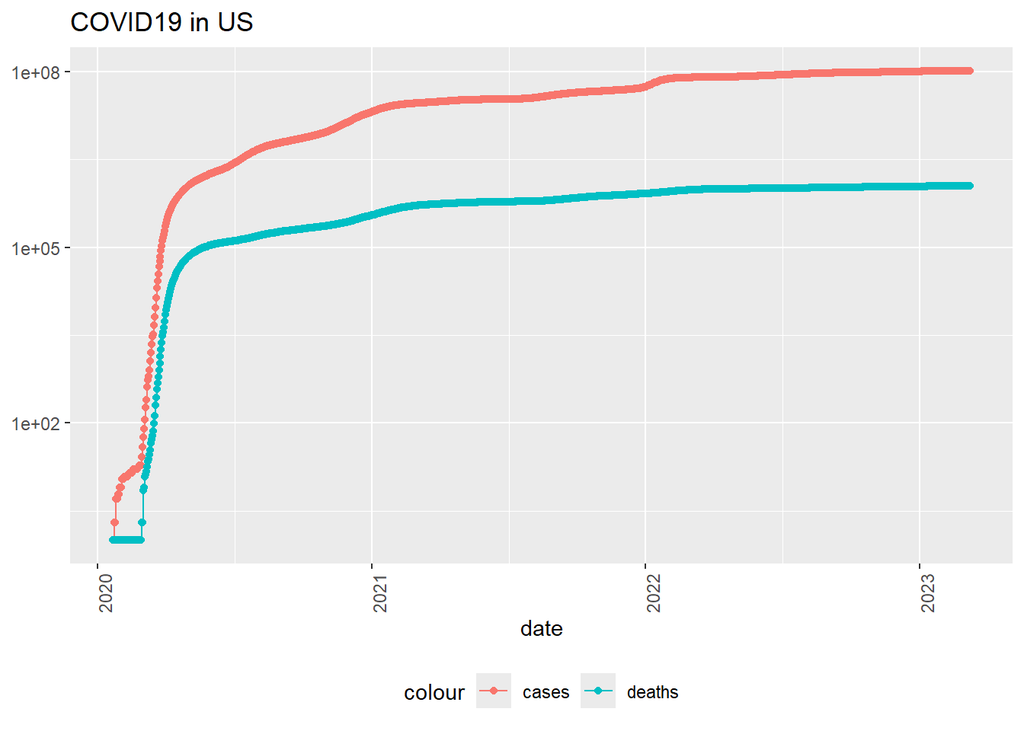

```r
US_totals %>%
  filter(cases > 0) %>%
  ggplot(aes(x = date, y = cases)) +
  geom_line(aes(color= "cases")) +
  geom_point(aes(color = "cases")) +
  geom_line(aes(y = deaths, color = "deaths")) +
  geom_point(aes(y= deaths, color = "deaths")) +
  scale_y_log10() +
  theme(legend.position = "bottom",
        axis.text.x = element_text(angle = 90)) +
  labs(title = "COVID19 in US", y = NULL)
```

This is the number of cases in whatever this color is, orange color and deaths in a turquoise. This gives us a visualization, of the total number of cases and deaths in the United States, from the start of the reporting of the COVID. Now we can do the same thing, and choose a state that we would like to look at. We just choose the state of New York. We will filter and take only that states where the province state is equal to the state of New York. Then we will do the same plot here.

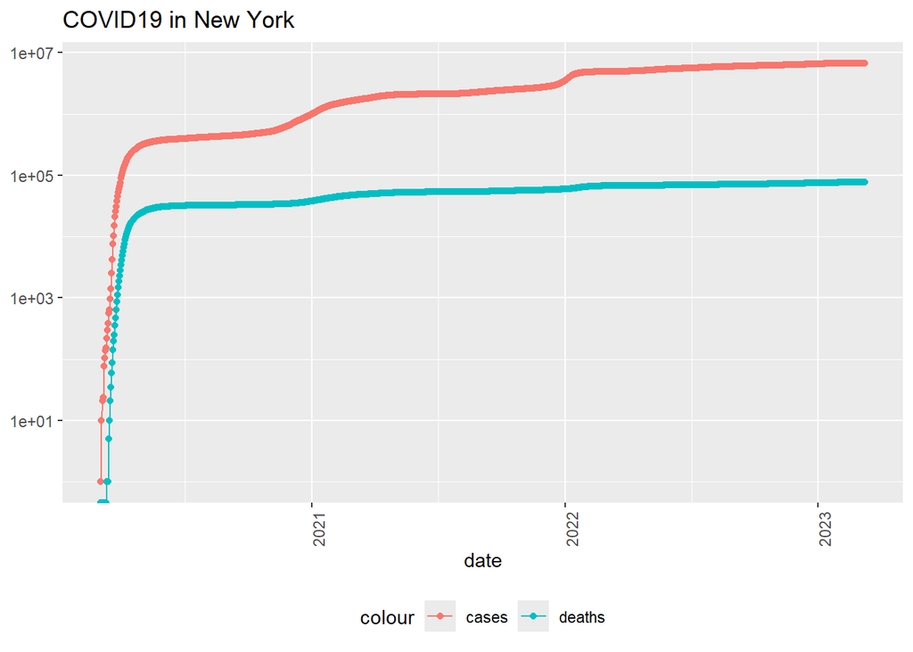

```r
state <- "New York"
US_by_state %>%
  filter(Province_State == state) %>%
  filter(cases > 0) %>%
  ggplot(aes(x = date, y = cases)) +
  geom_line(aes(color= "cases")) +
  geom_point(aes(color = "cases")) +
  geom_line(aes(y = deaths, color = "deaths")) +
  geom_point(aes(y= deaths, color = "deaths")) +
  scale_y_log10() +
  theme(legend.position = "bottom",
        axis.text.x = element_text(angle = 90)) +
  labs(title = str_c("COVID19 in ", state), y = NULL)
```

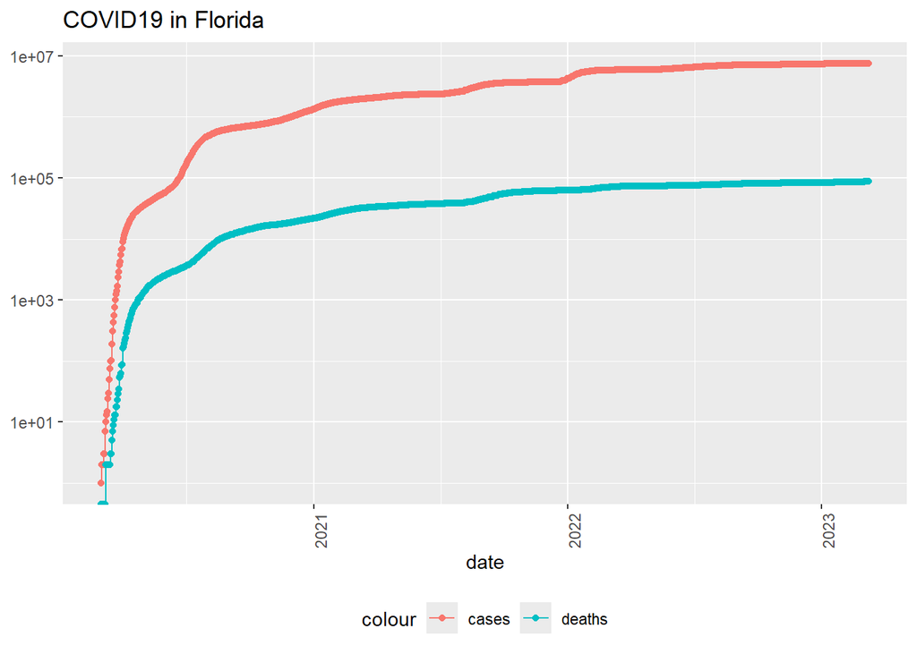

```r
state <- "Florida"
US_by_state %>%
  filter(Province_State == state) %>%
  filter(cases > 0) %>%
  ggplot(aes(x = date, y = cases)) +
  geom_line(aes(color= "cases")) +
  geom_point(aes(color = "cases")) +
  geom_line(aes(y = deaths, color = "deaths")) +
  geom_point(aes(y= deaths, color = "deaths")) +
  scale_y_log10() +
  theme(legend.position = "bottom",
        axis.text.x = element_text(angle = 90)) +
  labs(title = str_c("COVID19 in ", state), y = NULL)
```

We can see the COVID-19 and New York and Florida cases and can see what that growth has looked like, over time. These visualizations lead us to some questions. Let’s check what is the total maximum deaths for US and global. The fact that US_totals and global has the same max date and deaths shows that US is the leading country with the most covid deaths.

```r
max(US_totals$date)
```

```
## [1] "2023-03-09"
```

```r
max(US_totals$deaths)
```

```
## [1] 1123836
```

```r
max(global$date)
```

```
## [1] "2023-03-09"
```

```r
max(global$deaths)
```

```
## [1] 1123836
```

On our graph, it looks like the COVID cases have leveled off. Is that true? This visualization leads us to questions, which is going to take us back to do more of our transforming of our data, and then visualizing that. Now that we’ve done the basic visualization, before we do any modeling, this has raised questions about is the number of the number of new cases basically flat? Basically there are no new cases, because things have leveled off. Well, in order to analyze this, we are going to add our data, what we’re going to do is we will transform our data again, and what we will do is we will add new variables. We will call new cases to be the cases minus the lag of cases and new death. So we will add these two columns to our data sets.

```r
US_by_state <- US_by_state %>%
  mutate(new_cases = cases - lag(cases),
         new_deaths = deaths - lag(deaths))
US_totals <- US_totals %>%
  mutate(new_cases = cases - lag(cases),
         new_deaths = deaths - lag(deaths))
```

Let’s look at the US totals and let’s look at the tail of that.

```r
tail(US_totals)
```

```
## # A tibble: 6 × 8
##   Country_Region date          cases deaths deaths_per_mill Population new_cases
##   <chr>          <date>        <dbl>  <dbl>           <dbl>      <dbl>     <dbl>
## 1 US             2023-03-04   1.04e8 1.12e6           3371.  332875137      2147
## 2 US             2023-03-05   1.04e8 1.12e6           3371.  332875137     -3862
## 3 US             2023-03-06   1.04e8 1.12e6           3371.  332875137      8564
## 4 US             2023-03-07   1.04e8 1.12e6           3372.  332875137     35371
## 5 US             2023-03-08   1.04e8 1.12e6           3374.  332875137     64861
## 6 US             2023-03-09   1.04e8 1.12e6           3376.  332875137     46931
## # ℹ 1 more variable: new_deaths <dbl>
```

We want to see the new cases and the new deaths and then everything else. Now we can see the new cases or the new deaths per day in the US as well. Now that we got those variables added in, let’s look at the US first and see what this does.

```r
tail(US_totals %>% select (new_cases, new_deaths, everything()))
```

```
## # A tibble: 6 × 8
##   new_cases new_deaths Country_Region date          cases deaths deaths_per_mill
##       <dbl>      <dbl> <chr>          <date>        <dbl>  <dbl>           <dbl>
## 1      2147          7 US             2023-03-04   1.04e8 1.12e6           3371.
## 2     -3862        -38 US             2023-03-05   1.04e8 1.12e6           3371.
## 3      8564         47 US             2023-03-06   1.04e8 1.12e6           3371.
## 4     35371        335 US             2023-03-07   1.04e8 1.12e6           3372.
## 5     64861        730 US             2023-03-08   1.04e8 1.12e6           3374.
## 6     46931        590 US             2023-03-09   1.04e8 1.12e6           3376.
## # ℹ 1 more variable: Population <dbl>
```

Now we are going to look at the US and we are going to graph the new cases and the new deaths.

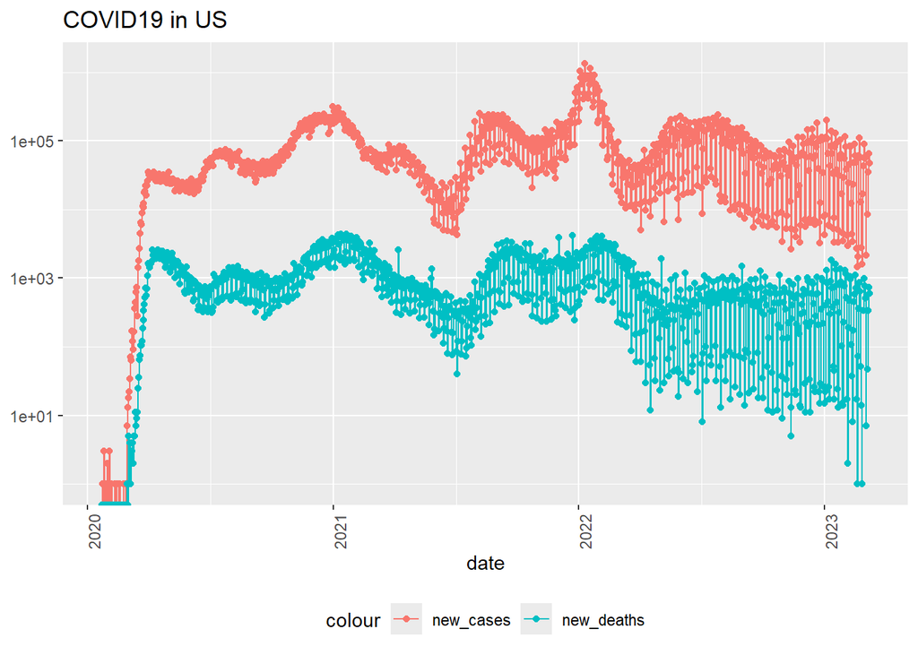

```r
US_totals %>%
  ggplot(aes(x = date, y = new_cases)) +
  geom_line(aes(color= "new_cases")) +
  geom_point(aes(color = "new_cases")) +
  geom_line(aes(y = new_deaths, color = "new_deaths")) +
  geom_point(aes(y= new_deaths, color = "new_deaths")) +
  scale_y_log10() +
  theme(legend.position = "bottom",
        axis.text.x = element_text(angle = 90)) +
  labs(title = "COVID19 in US", y = NULL)
```

It still seems we still have the same number of new cases per day and the number of new deaths per day. But it has flattened out. It is still up a little bit over what it was before. But we can see where the cases are. When we’ve lived through this COVID-19 crisis, the media and everyone started by looking at the total number of cases. But quickly that lost its ability to communicate anything to us because we were even looking at an exponential graph or if we’re looking at a log scale which is flattened out. We wanted to look at the new cases per day and try to see what those were doing. We can do the same thing now for the state of New York, and let’s see what’s happening in New York. If we look at New York, we can see, it had a nice dip down, but then it came back up. It’s currently seems to be tailing back off, but it’s still reasonably high. This is the way we transform our data and then visualize it again, and we can go through this process over and over as this process will bring up different questions for us to look at. One of the things we may want to know is, what are the worst and best states and how do we measure this? Should we look at the total cases or the death rates per 1,000 people? We want to do a little more analysis.

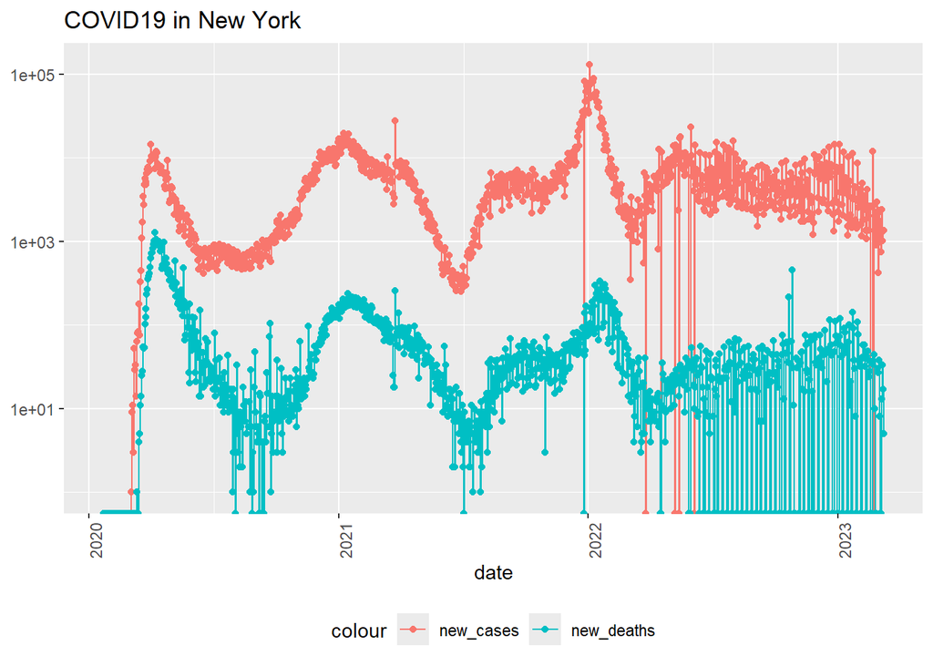

```r
state <- "New York"
US_by_state %>%
  filter(Province_State == state) %>%
  ggplot(aes(x = date, y = new_cases)) +
  geom_line(aes(color= "new_cases")) +
  geom_point(aes(color = "new_cases")) +
  geom_line(aes(y = new_deaths, color = "new_deaths")) +
  geom_point(aes(y= new_deaths, color = "new_deaths")) +
  scale_y_log10() +
  theme(legend.position = "bottom",
        axis.text.x = element_text(angle = 90)) +
  labs(title = str_c("COVID19 in ", state), y = NULL)
```

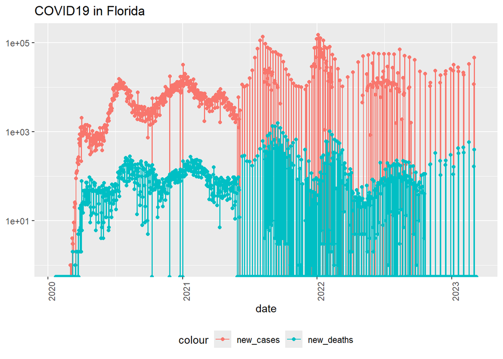

```r
state <- "Florida"
US_by_state %>%
  filter(Province_State == state) %>%
  ggplot(aes(x = date, y = new_cases)) +
  geom_line(aes(color= "new_cases")) +
  geom_point(aes(color = "new_cases")) +
  geom_line(aes(y = new_deaths, color = "new_deaths")) +
  geom_point(aes(y= new_deaths, color = "new_deaths")) +
  scale_y_log10() +
  theme(legend.position = "bottom",
        axis.text.x = element_text(angle = 90)) +
  labs(title = str_c("COVID19 in ", state), y = NULL)
```

Now we’ll transform on data once again to group by state and then within that, we will chose the maximum deaths, the maximum cases for the state, and then the population for the state, and compute the deaths per 1,000 and the cases we 1,000 and then we are going to filter out where the cases are bigger than zero and the population is bigger than zero.

```r
US_state_totals <- US_by_state %>%
  group_by(Province_State) %>%
  summarize(deaths = max(deaths), cases = max(cases),
            population = max(Population),
            cases_per_thou = 1000*cases/population,
            deaths_per_thou = 1000* deaths/population) %>%
  filter(cases > 0, population >0)
```

Now we can take what we have in US state totals. We will use a verb called slice min, which will tell us the states with the smallest deaths per 1,000. These are the deaths per 1,000.

```r
US_state_totals %>%
  slice_min(deaths_per_thou, n = 10)
```

```
## # A tibble: 10 × 6
##    Province_State        deaths  cases population cases_per_thou deaths_per_thou
##    <chr>                  <dbl>  <dbl>      <dbl>          <dbl>           <dbl>
##  1 American Samoa            34 8.32e3      55641           150.           0.611
##  2 Northern Mariana Isl…     41 1.37e4      55144           248.           0.744
##  3 Virgin Islands           130 2.48e4     107268           231.           1.21
##  4 Hawaii                  1841 3.81e5    1415872           269.           1.30
##  5 Vermont                  929 1.53e5     623989           245.           1.49
##  6 Puerto Rico             5823 1.10e6    3754939           293.           1.55
##  7 Utah                    5298 1.09e6    3205958           340.           1.65
##  8 Alaska                  1486 3.08e5     740995           415.           2.01
##  9 District of Columbia    1432 1.78e5     705749           252.           2.03
## 10 Washington             15683 1.93e6    7614893           253.           2.06
```

```r
US_state_totals %>%
  slice_min(deaths_per_thou, n = 10) %>%
select(deaths_per_thou, cases_per_thou, everything())
```

```
## # A tibble: 10 × 6
##    deaths_per_thou cases_per_thou Province_State        deaths  cases population
##              <dbl>          <dbl> <chr>                  <dbl>  <dbl>      <dbl>
##  1           0.611           150. American Samoa            34 8.32e3      55641
##  2           0.744           248. Northern Mariana Isl…     41 1.37e4      55144
##  3           1.21            231. Virgin Islands           130 2.48e4     107268
##  4           1.30            269. Hawaii                  1841 3.81e5    1415872
##  5           1.49            245. Vermont                  929 1.53e5     623989
##  6           1.55            293. Puerto Rico             5823 1.10e6    3754939
##  7           1.65            340. Utah                    5298 1.09e6    3205958
##  8           2.01            415. Alaska                  1486 3.08e5     740995
##  9           2.03            252. District of Columbia    1432 1.78e5     705749
## 10           2.06            253. Washington             15683 1.93e6    7614893
```

We can see now the deaths per 1,000 rates and the cases per 1,000 rates and this states that have the lowest deaths per 1,000 rate. We can also look at the worst cases. Which are the worst states?

```r
US_state_totals %>%
  slice_max(deaths_per_thou, n = 10) %>%
select(deaths_per_thou, cases_per_thou, everything())
```

```
## # A tibble: 10 × 6
##    deaths_per_thou cases_per_thou Province_State deaths   cases population
##              <dbl>          <dbl> <chr>           <dbl>   <dbl>      <dbl>
##  1            4.55           336. Arizona         33102 2443514    7278717
##  2            4.54           326. Oklahoma        17972 1290929    3956971
##  3            4.49           333. Mississippi     13370  990756    2976149
##  4            4.44           359. West Virginia    7960  642760    1792147
##  5            4.32           320. New Mexico       9061  670929    2096829
##  6            4.31           334. Arkansas        13020 1006883    3017804
##  7            4.29           335. Alabama         21032 1644533    4903185
##  8            4.28           368. Tennessee       29263 2515130    6829174
##  9            4.23           307. Michigan        42205 3064125    9986857
## 10            4.06           385. Kentucky        18130 1718471    4467673
```

Now we can see which states fair to be the worst of all the states so far in terms of their deaths per 1,000 people due to COVID. This just is a different way to analyze the data. There’s a lot of different ways we could look at the data. It’s important to remember that as we do this analysis, we should always be asking the questions. Are the deaths reported the same in all of these places? Do we trust the data that we are looking at? Just because we got a set of numbers does not mean we can use it without thinking about where the data came from, how we was reported and how valid it is.

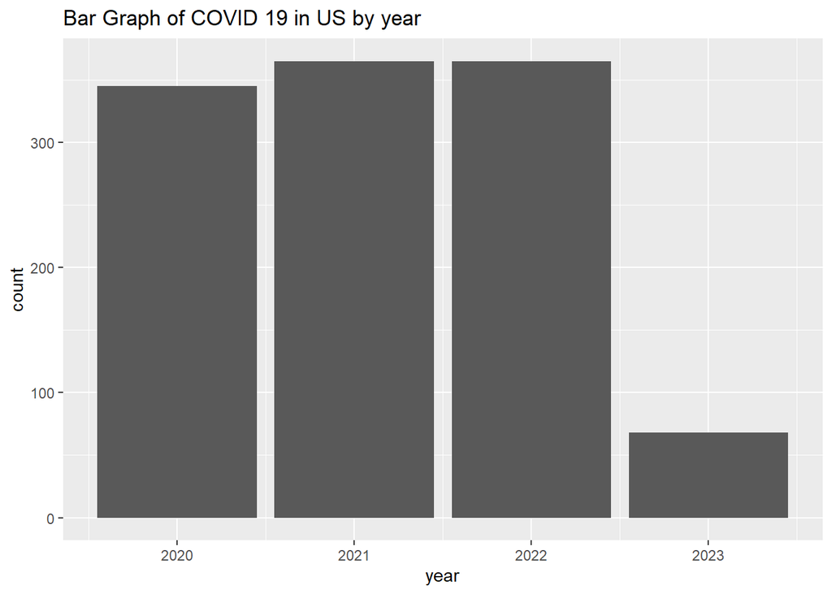

```r
US_totals$year <- year(US_totals$date)

US_totals %>%
  ggplot(aes(x =year)) +
  geom_bar() +
  labs(title = "Bar Graph of COVID 19 in US by year")
```

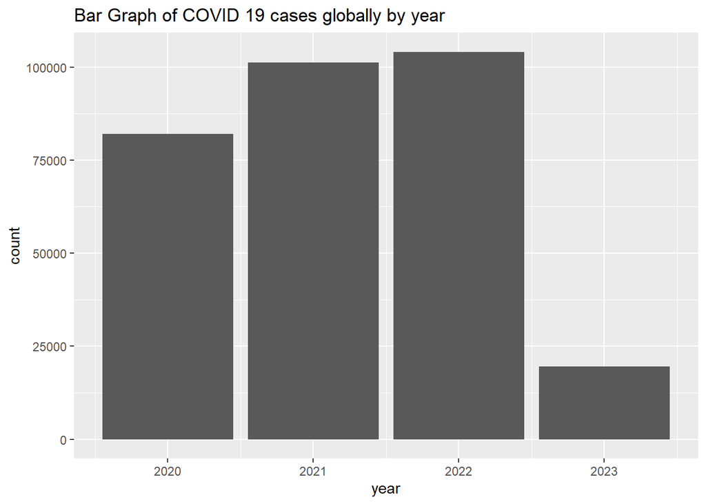

```r
global$year <- year(global$date)

global %>%
     ggplot(aes(x =year)) +
     geom_bar() +
     labs(title = "Bar Graph of COVID 19 cases globally by year")
```

## Modeling the Data

```r
mod <- lm(deaths_per_thou ~ cases_per_thou, data = US_state_totals)
```

Let’s look at how many cases per 1,000 are the smallest and how many are the largest.

```r
US_state_totals %>% slice_min(cases_per_thou)
```

```
## # A tibble: 1 × 6
##   Province_State deaths cases population cases_per_thou deaths_per_thou
##   <chr>           <dbl> <dbl>      <dbl>          <dbl>           <dbl>
## 1 American Samoa     34  8320      55641           150.           0.611
```

```r
US_state_totals %>% slice_max(cases_per_thou)
```

```
## # A tibble: 1 × 6
##   Province_State deaths  cases population cases_per_thou deaths_per_thou
##   <chr>           <dbl>  <dbl>      <dbl>          <dbl>           <dbl>
## 1 Rhode Island     3870 460697    1059361           435.            3.65
```

```r
US_state_totals %>% mutate(pred = predict(mod))
```

```
## # A tibble: 56 × 7
##    Province_State  deaths  cases population cases_per_thou deaths_per_thou  pred
##    <chr>            <dbl>  <dbl>      <dbl>          <dbl>           <dbl> <dbl>
##  1 Alabama          21032 1.64e6    4903185           335.           4.29   3.44
##  2 Alaska            1486 3.08e5     740995           415.           2.01   4.34
##  3 American Samoa      34 8.32e3      55641           150.           0.611  1.33
##  4 Arizona          33102 2.44e6    7278717           336.           4.55   3.44
##  5 Arkansas         13020 1.01e6    3017804           334.           4.31   3.42
##  6 California      101159 1.21e7   39512223           307.           2.56   3.12
##  7 Colorado         14181 1.76e6    5758736           306.           2.46   3.11
##  8 Connecticut      12220 9.77e5    3565287           274.           3.43   2.74
##  9 Delaware          3324 3.31e5     973764           340.           3.41   3.49
## 10 District of Co…   1432 1.78e5     705749           252.           2.03   2.49
## # ℹ 46 more rows
```

Now the prediction is going to be added in as the variable pred. We want to make that part of the data set. So, let’s make a new data set where we call it US total with predictions, where we adding those together. So we can look at that and see, that we in fact have the deaths per 1,000 and the predictions.

```r
US_tot_w_pred <- US_state_totals %>% mutate(pred = predict(mod))
US_tot_w_pred
```

```
## # A tibble: 56 × 7
##    Province_State  deaths  cases population cases_per_thou deaths_per_thou  pred
##    <chr>            <dbl>  <dbl>      <dbl>          <dbl>           <dbl> <dbl>
##  1 Alabama          21032 1.64e6    4903185           335.           4.29   3.44
##  2 Alaska            1486 3.08e5     740995           415.           2.01   4.34
##  3 American Samoa      34 8.32e3      55641           150.           0.611  1.33
##  4 Arizona          33102 2.44e6    7278717           336.           4.55   3.44
##  5 Arkansas         13020 1.01e6    3017804           334.           4.31   3.42
##  6 California      101159 1.21e7   39512223           307.           2.56   3.12
##  7 Colorado         14181 1.76e6    5758736           306.           2.46   3.11
##  8 Connecticut      12220 9.77e5    3565287           274.           3.43   2.74
##  9 Delaware          3324 3.31e5     973764           340.           3.41   3.49
## 10 District of Co…   1432 1.78e5     705749           252.           2.03   2.49
## # ℹ 46 more rows
```

So now let’s take that data set and let’s plot both the actuals and the predictions to see how well we’re doing. So we will feed that into ggplot and then we will add in points for both the, let’s add points for the real cases. So x is cases per 1,000 and y is deaths per 1,000, we’ll make those blue. And then let’s add in our predictions in red and see how that does.

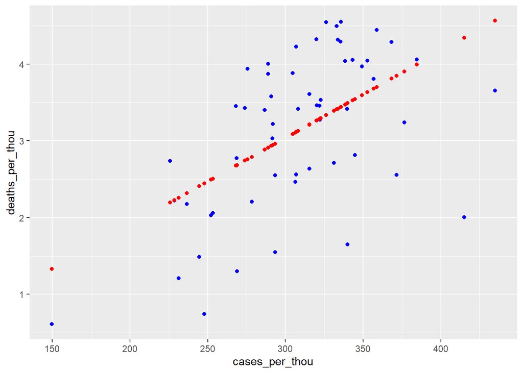

```r
US_tot_w_pred %>% ggplot() +
  geom_point(aes(x=cases_per_thou, y = deaths_per_thou), color = "blue") +
  geom_point(aes(x=cases_per_thou, y = pred), color= "red")
```

## Bias Identification

Where does bias come into your data science process? well there’s all sorts of bias sources, and they begin at the very beginning of your data science process. Your bias sources even start with the topic you choose to work on, For example your interest and feeling about the topic. They even extend to what are the variables you measure? For the COVID analysis, we are looking at cases, total cases and total deaths.

1. Selection Bias  
   Only COVID cases that are reported are recorded in data set. Many people have COVID and quarantine at home or died from COVID, but not report it. Since these cases and deaths that are not in this data and analysis, leading to possible skewed results.
2. Reporting Bias  
   Some states may intentionally unrepresented the number of COVID cases they have due to being prideful that they have the COVID cases under control.
3. Measurement Bias  
   There can be incorrect recording of number of COVID cases, deaths, and the number population.
4. Detection Bias  
   When reporting the incidents, there can be detection bias, such as misidentifying where one has COVID or not.